# Section 15: Linear Regression

```r
library(tidyverse)
```

```r
# Set all plots in this section to have "minima" theme - looks cleaner
theme_set(theme_minimal())
```

## Correlation

A scatterplot shows a downward trend between year and freeze duration.

```r
monona <- read_csv("../../data/lake-monona-winters-2025.csv")
```

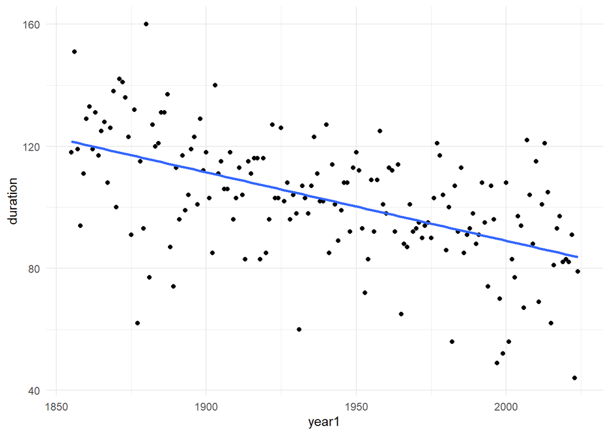

```r
ggplot(monona, aes(x = year1, y = duration)) +
  geom_point() +
  geom_smooth(method = "lm", se = F)
```

We can calculate correlation with the `cor` function.

```r
x <- monona$year1
y <- monona$duration

cor(x, y)
```

```
## [1] -0.5482328
```

```r
cor(y, x)
```

```
## [1] -0.5482328
```

### Correlation examples

```r
# Hide this chunk - just for the purpose of making example plots

set.seed(2023)
x1 = seq(-2,2,0.05)
y0 = rnorm(length(x1))
y1 = x1^2
x2 = x1[x1>0]
y2 = y1[x1>0]
x3 = x1[x1<0]
y3 = y1[x1<0]
x4 = x1
y4 = x4 + rnorm(length(x4),0,0.3)
x5 = x1
y5 = x5 + rnorm(length(x5),0,1)
x6 = x1[x1 > -1]
y6 = exp(3*x6)/10 + rnorm(length(x6), 0, 5)

cor_plot = function(x,y)
{
  ggplot(tibble(x,y), aes(x=x, y=y)) +
    geom_point() +
    geom_smooth(se = FALSE, method = "lm") +
    ggtitle(str_c("r ≈ ", round(cor(x,y),2))) +
  theme_bw() +
  theme(text = element_text(size = 20))
}
```

Correlation 0 corresponds to no linear relationship. This can be a horizontal line or some other shape.

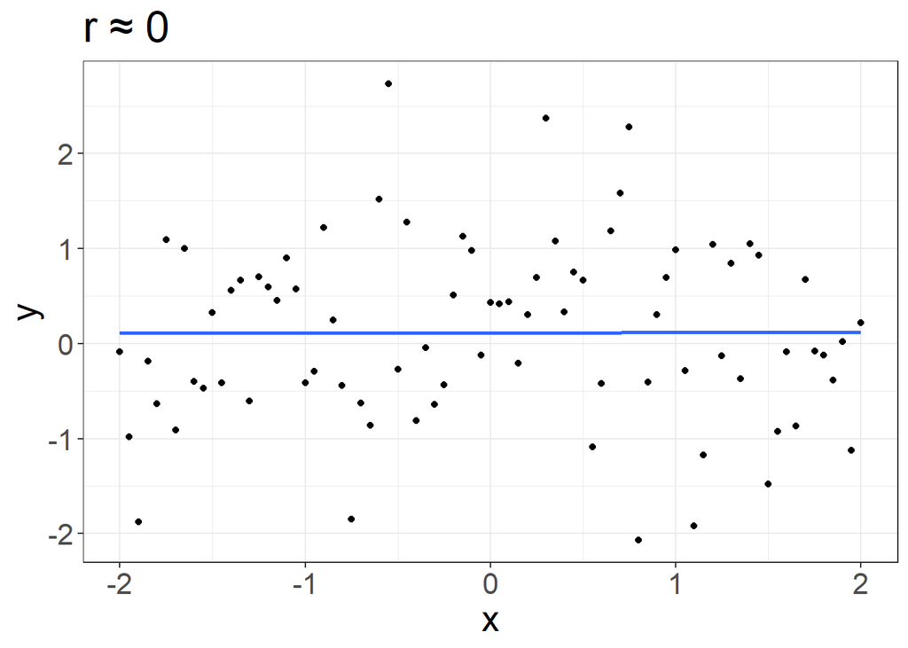

```r
cor_plot(x1, y0)
```

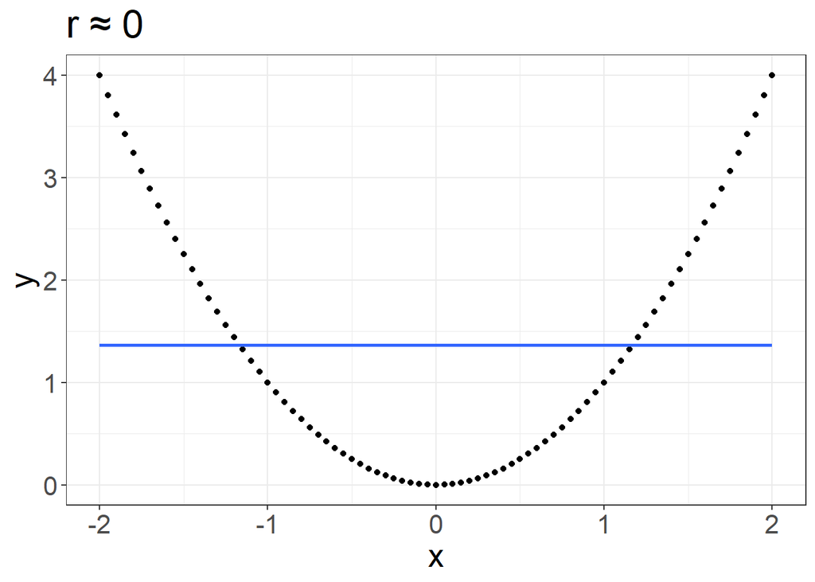

```r
cor_plot(x1, y1)
```

Correlation near 1 or -1 indicates that a line fits the data well. This does not necessarily imply a true linear relationship.

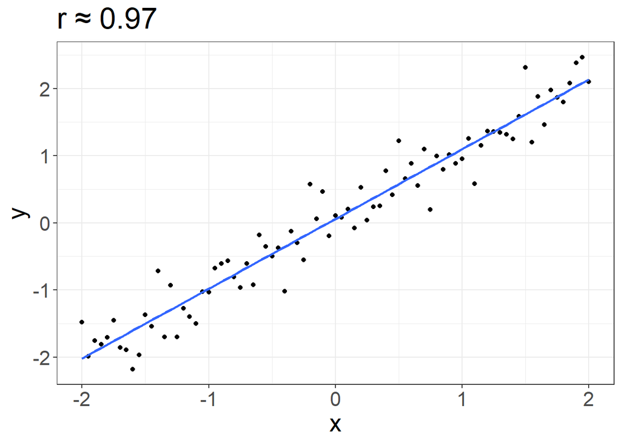

```r
cor_plot(x4, y4)
```

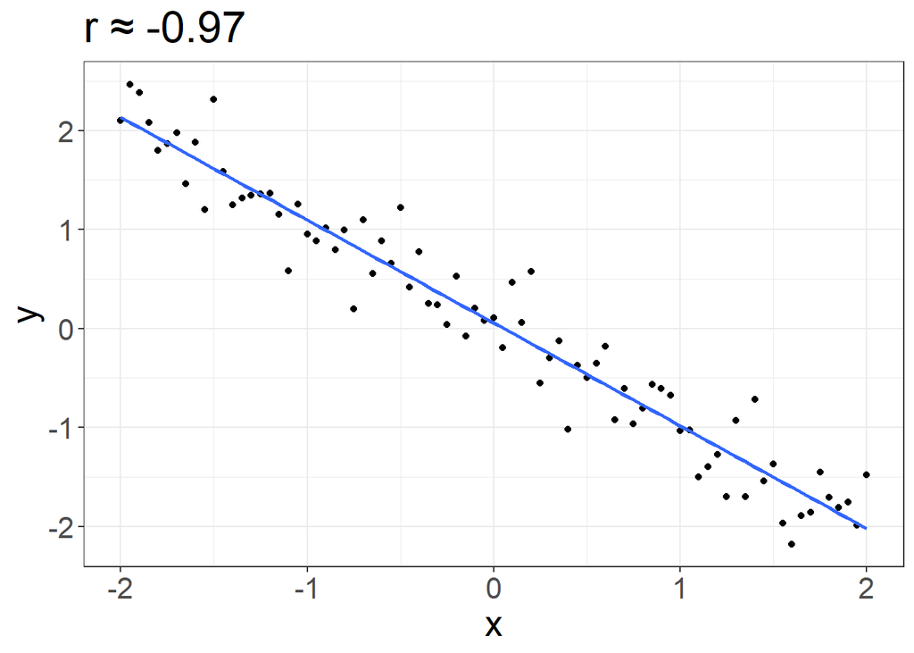

```r
cor_plot(-x4, y4)
```

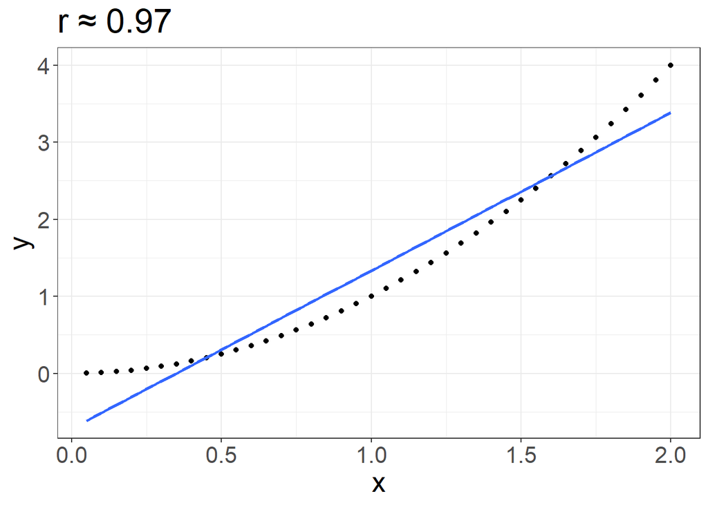

```r
cor_plot(x2, y2)
```

A correlation of 0.7 indicates that a line fits the data somewhat well. Again, there maybe some other underlying relationship.

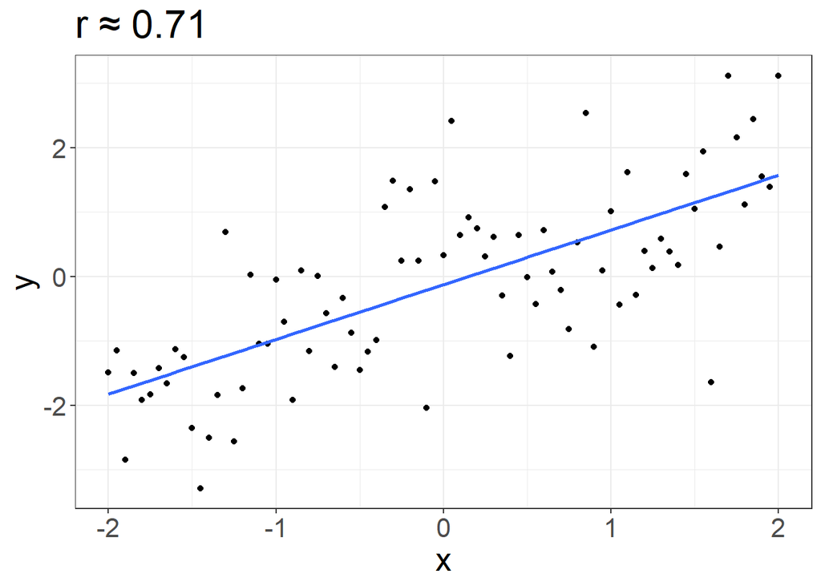

```r
cor_plot(x5, y5)
```

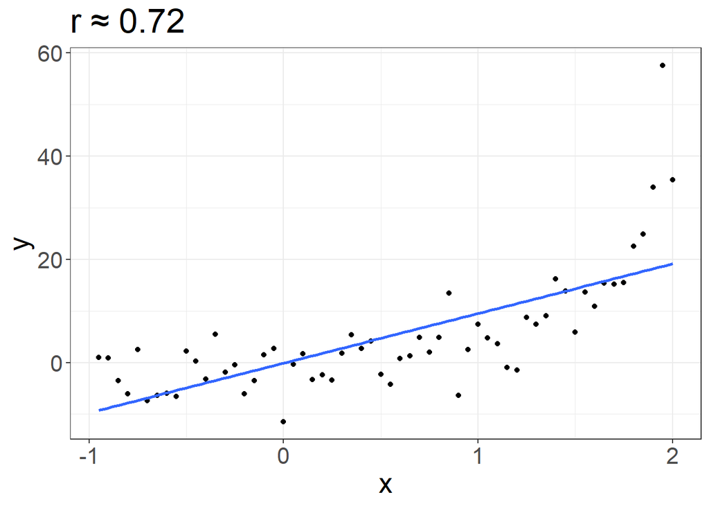

```r
cor_plot(x6, y6)
```

An example motivated by real life: what is the relationship between a baseball team’s winning percentage and the latitude of its stadium?

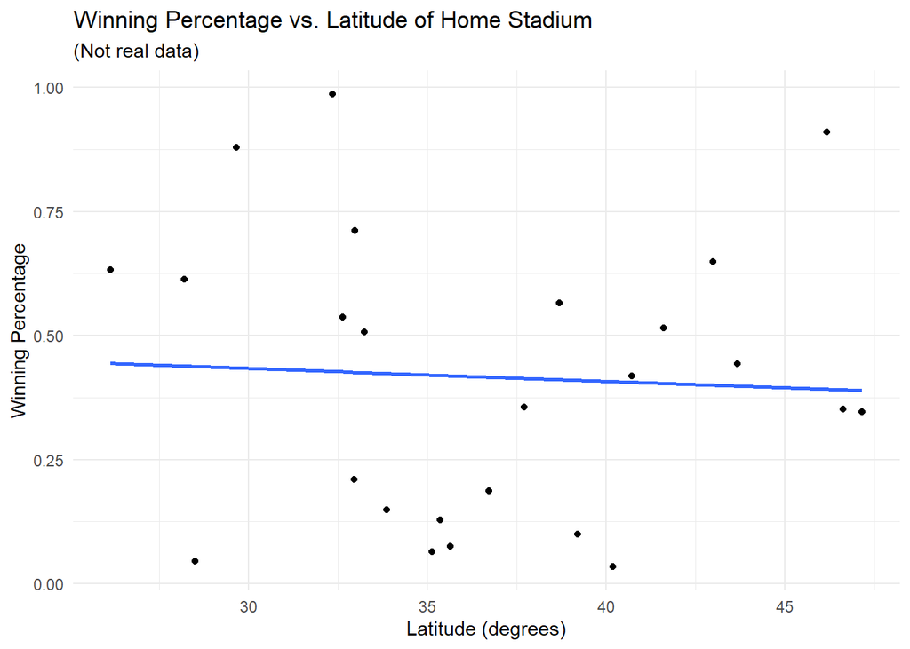

```r
set.seed(20240406)
fake_latitude <- tibble(
  win_perc = runif(25, 0, 1),
  latitude = runif(25, 25, 48)
)

ggplot(fake_latitude, aes(latitude, win_perc)) +
  geom_point() +
  geom_smooth(method = "lm", se = F) +
  labs(title = "Winning Percentage vs. Latitude of Home Stadium",
       subtitle = "(Not real data)",
       y = "Winning Percentage",
       x = "Latitude (degrees)")
```

Now, consider predicting the winning percentage based on average wages.

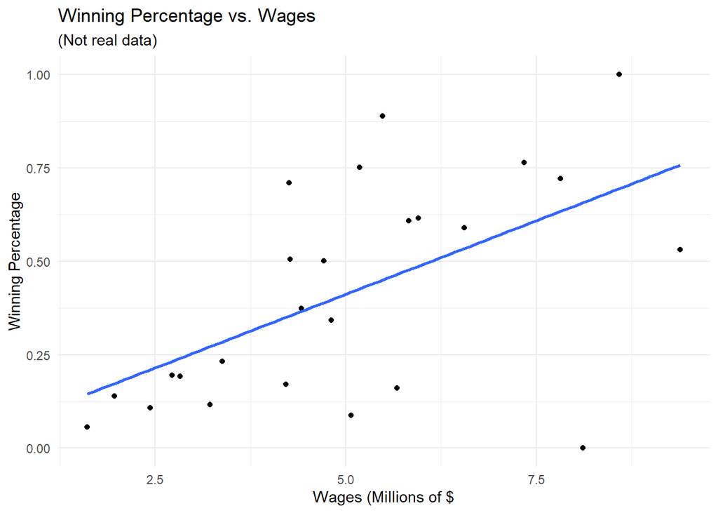

```r
set.seed(20240406)
fake_wages <- tibble(
  wages = rnorm(25, 5, 2),
  win_perc = wages* rnorm(25, 1, 0.5),
  win_perc_adj = (win_perc - min(win_perc))/max(win_perc - min(win_perc))
)

ggplot(fake_wages, aes(wages, win_perc_adj)) +
  geom_point() +
  geom_smooth(method = "lm", se = F) +
  labs(title = "Winning Percentage vs. Wages",
       subtitle = "(Not real data)",
       y = "Winning Percentage",
       x = "Wages (Millions of $")
```

## Linear modeling

### Exercise

```r
riley <- read_table("../../data/riley.txt")
riley_2_8 <- riley %>%
  filter(age >= 24 & age <= 96)

# Find estimates for beta_0 and beta_1

sy <- sd(riley_2_8$height)
sx <- sd(riley_2_8$age)
r <- cor(riley_2_8$height, riley_2_8$age)

beta1 <- r * (sy/sx)
beta1
```

```
## [1] 0.2505185
```

```r
xbar <- mean(riley_2_8$age)
ybar <- mean(riley_2_8$height)

beta0 <- ybar - beta1 * xbar
beta0
```

```
## [1] 30.24933
```

We can fit a linear model automatically with `lm`.

```r
lm(height ~ age, data = riley_2_8)
```

```
##
## Call:
## lm(formula = height ~ age, data = riley_2_8)
##
## Coefficients:
## (Intercept)          age
##     30.2493       0.2505
```

```r
# It's helpful to save the result to reference it later
height_mod <- lm(height ~ age, data = riley_2_8)

summary(height_mod)
```

```
##
## Call:
## lm(formula = height ~ age, data = riley_2_8)
##
## Residuals:
##      Min       1Q   Median       3Q      Max
## -0.29911 -0.19291 -0.03355  0.21982  0.46334
##
## Coefficients:
##              Estimate Std. Error t value Pr(>|t|)
## (Intercept) 30.249329   0.186745  161.98   <2e-16 ***
## age          0.250519   0.002869   87.33   <2e-16 ***
## ---
## Signif. codes:  0 '***' 0.001 '**' 0.01 '*' 0.05 '.' 0.1 ' ' 1
##
## Residual standard error: 0.2429 on 14 degrees of freedom
## Multiple R-squared:  0.9982, Adjusted R-squared:  0.998
## F-statistic:  7627 on 1 and 14 DF,  p-value: < 2.2e-16
```

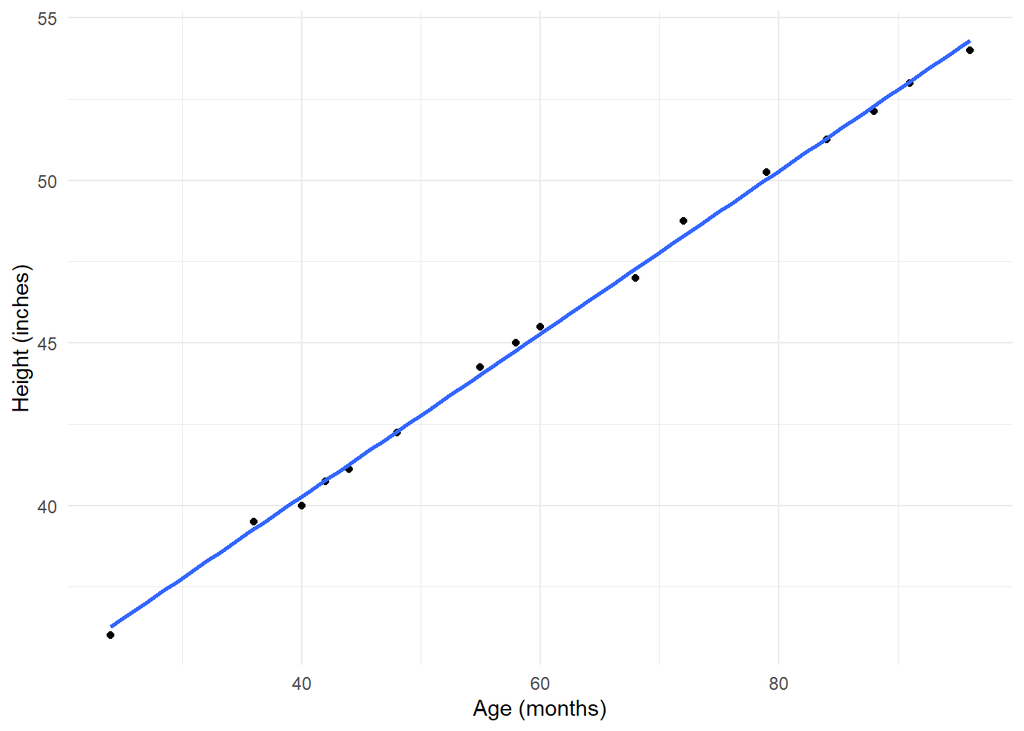

```r
ggplot(riley_2_8, aes(x = age, y = height)) +
  geom_point() +
  geom_smooth(se = FALSE, method = "lm") +
  ylab("Height (inches)") +
  xlab("Age (months)")
```

We can also do this for our Lake Monona data.

```r
lake_mod <- lm(duration ~ year1, data = monona)
```

## Assumptions

We evaluate the assumptions (i.e., validate the linear model fit) by studying the residuals. For ease of graphing, we can add the residuals to our data.

```r
resid(lake_mod)
```

[output not shown]

```r
monona_resids <- monona %>%
  mutate(residuals = resid(lake_mod)) %>%
  select(year1, duration, residuals)

monona_resids
```

```
## # A tibble: 170 × 3
##    year1 duration residuals
##    <dbl>    <dbl>     <dbl>
##  1  1855      118    -3.54
##  2  1856      151    29.7
##  3  1857      119    -2.10
##  4  1858       94   -26.9
##  5  1859      111    -9.65
##  6  1860      129     8.58
##  7  1861      133    12.8
##  8  1862      119    -0.976
##  9  1863      131    11.2
## 10  1864      117    -2.53
## # ℹ 160 more rows
```

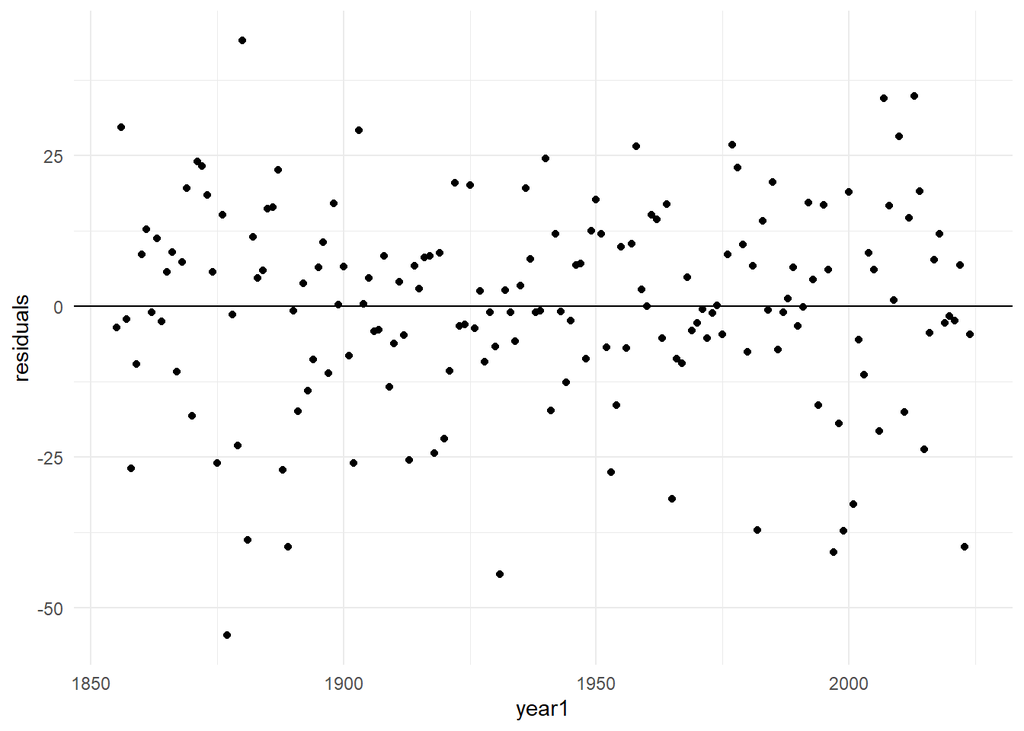

```r
monona_resids %>%
  ggplot(aes(x = year1, y = residuals)) +
  geom_point() +
  geom_hline(yintercept = 0)
```

### Linearity

```r
# This is just a helpful function so I don't have to type this out every time;
# feel free to use it yourself or not as you like

resid_plot <- function(data) {
  # assumes the columns are named "x" and "y" respectively
  data %>%
    mutate(resid = resid(lm(y~x, data))) %>%
    ggplot(aes(x, resid)) +
    geom_point() +
    geom_hline(yintercept = 0)
}
```

There should be no obvious curved patterns in a residual plot.

```r
set.seed(2024543)
linear_data <- tibble(
  x = runif(100, 0, 10),
  y = 0.05 * (x - 5) + rnorm(100, sd = 0.5)
)

nonlinear_data <- tibble(
  x = runif(100, 0, 10),
  y = 0.05 * (x - 5)^2 + rnorm(100, sd = 0.5)
)
```

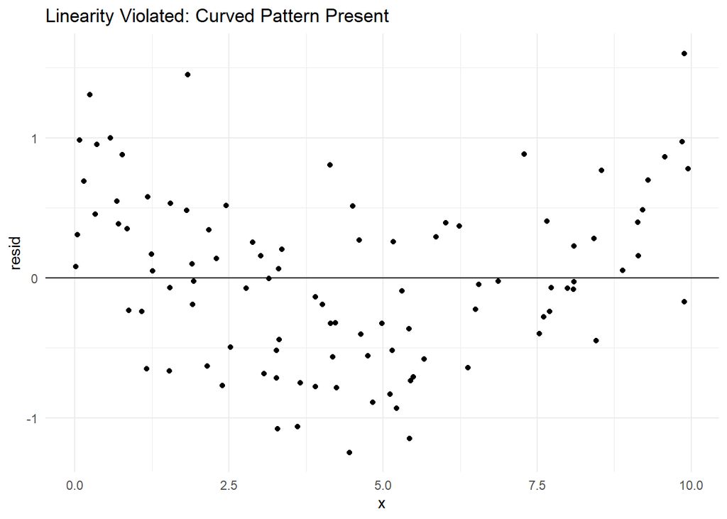

```r
resid_plot(nonlinear_data) +
  ggtitle("Linearity Violated: Curved Pattern Present")
```

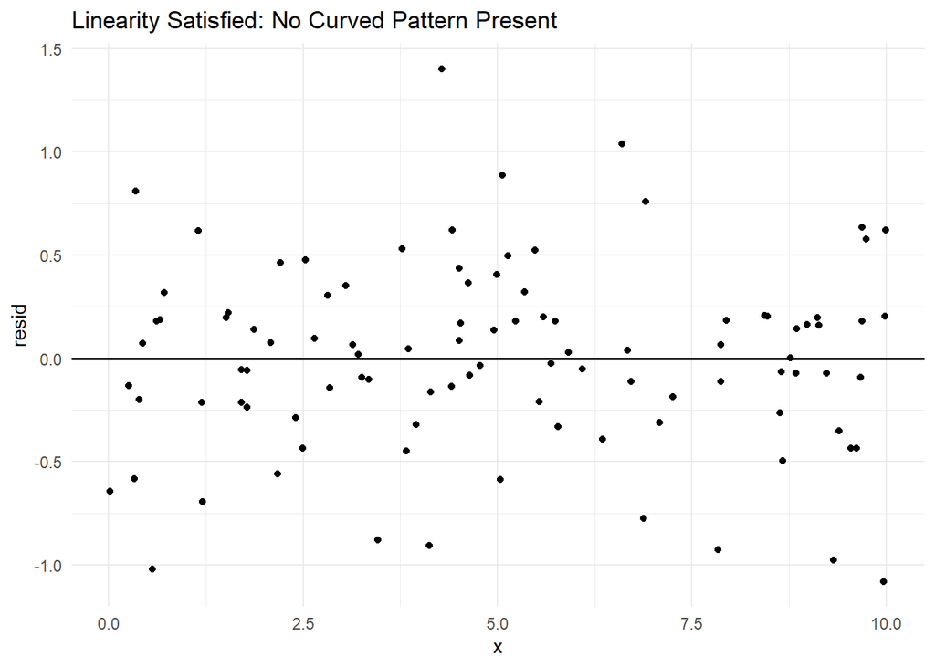

```r
resid_plot(linear_data) +
  ggtitle("Linearity Satisfied: No Curved Pattern Present")
```

### Normality

The points in a residual plot should be evenly scattered around the center horizontal line at 0.

```r
set.seed(20240407)
nonnormal_data <- tibble(
  x = runif(100, 0, 10),
  y = 0.05 * (x - 5) + sample(c(-2, 2), 100, replace = TRUE) * rnorm(100, mean = 1, sd = 0.5)
)

set.seed(20240407)
nonnormal_data2 <- tibble(
  x = runif(100, 0, 10),
  y = 2*x + rgamma(100, 1) - 1
)
```

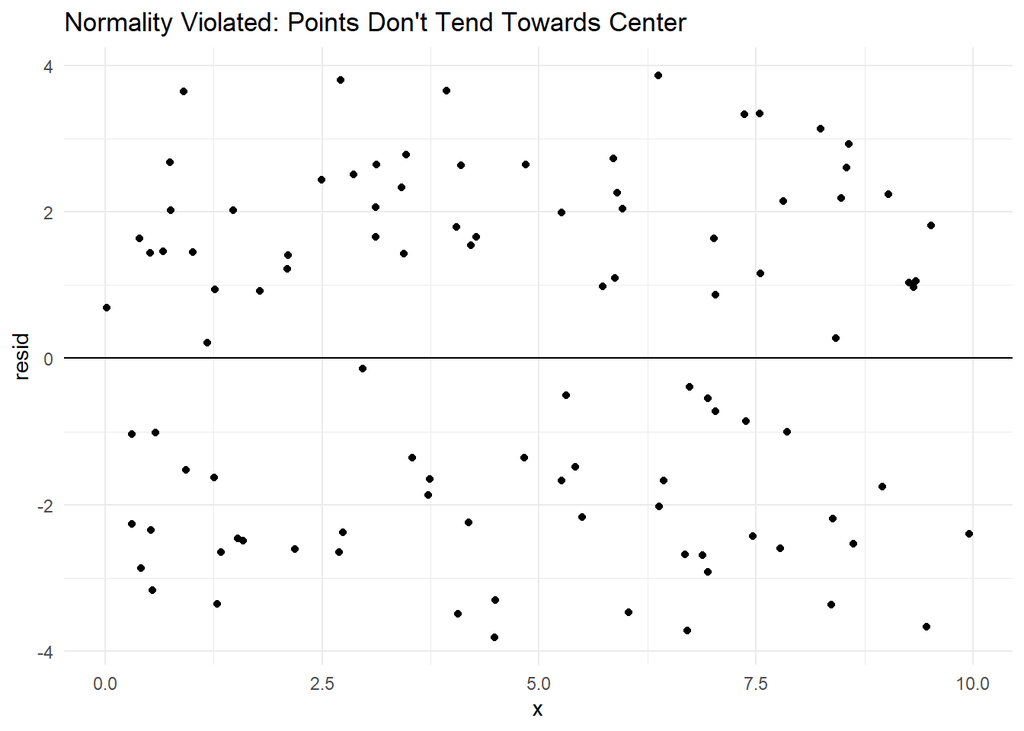

```r
resid_plot(nonnormal_data) +
  ggtitle("Normality Violated: Points Don't Tend Towards Center")
```

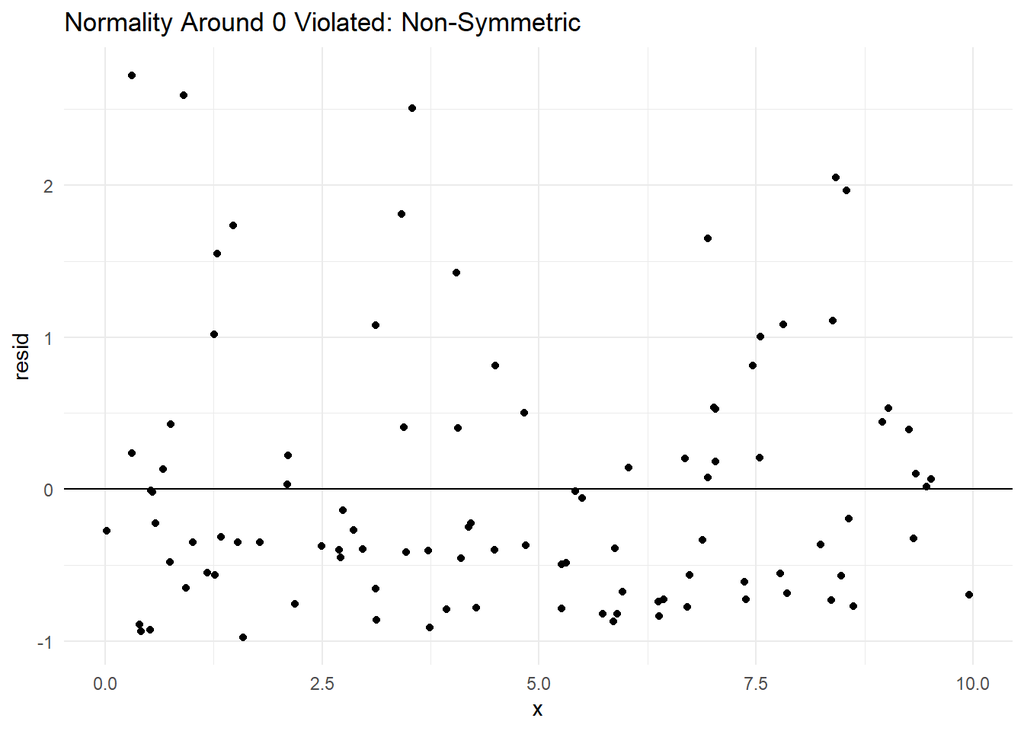

```r
resid_plot(nonnormal_data2) +
  ggtitle("Normality Around 0 Violated: Non-Symmetric")
```

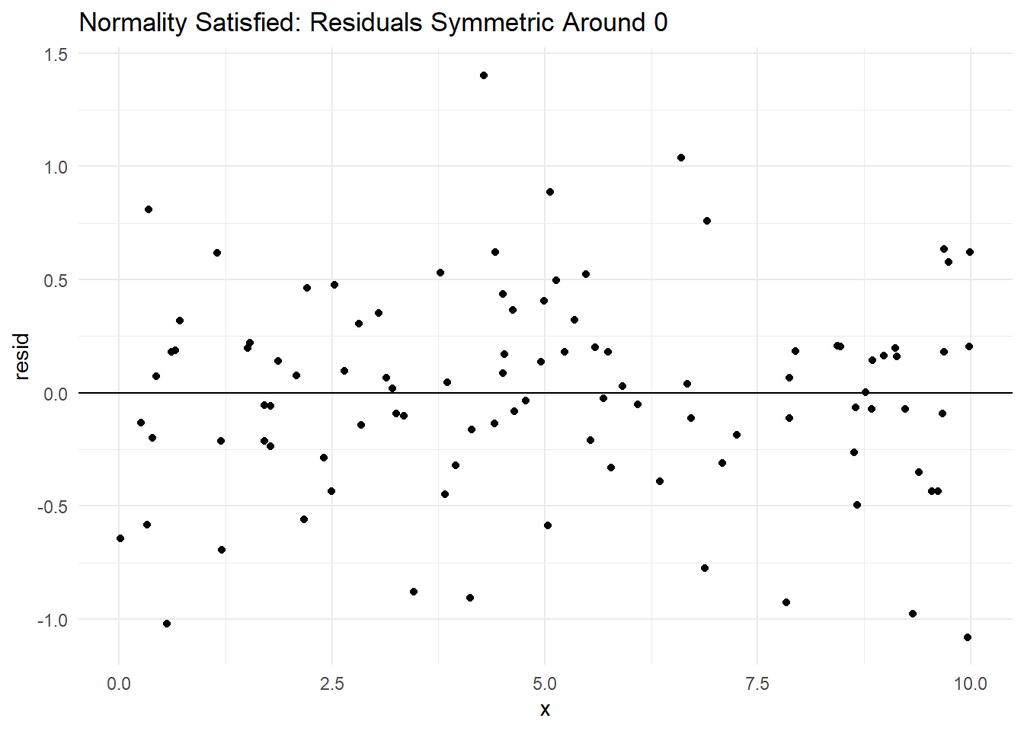

```r
resid_plot(linear_data) +
  ggtitle("Normality Satisfied: Residuals Symmetric Around 0")
```

### Constant variance

The residual plot should show no relationship between x and the spread of residuals. We don’t want to see a “megaphone” shape.

```r
set.seed(20240407)
heteroskedastic_data <- tibble(
  x = runif(100, 0, 10),
  y = x + rnorm(100, sd = 0.5 * x)
)

heteroskedastic_data2 <- tibble(
  x = runif(100, 0, 10),
  y = x + rnorm(100, sd = 0.5 * (10-x))
)
```

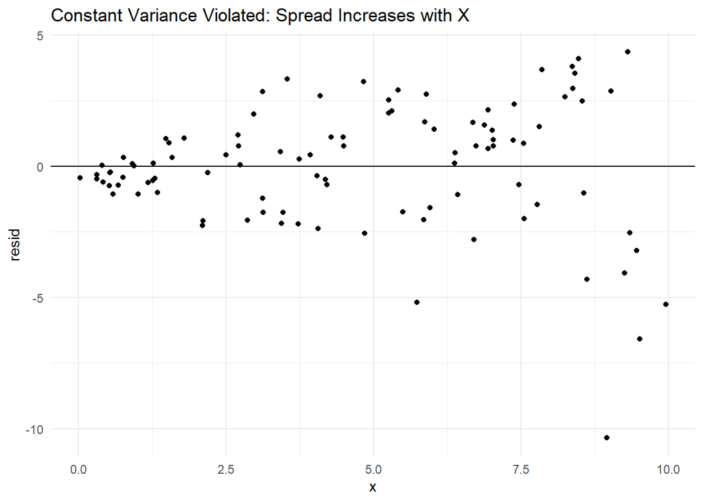

```r
resid_plot(heteroskedastic_data) +
  ggtitle("Constant Variance Violated: Spread Increases with X")
```

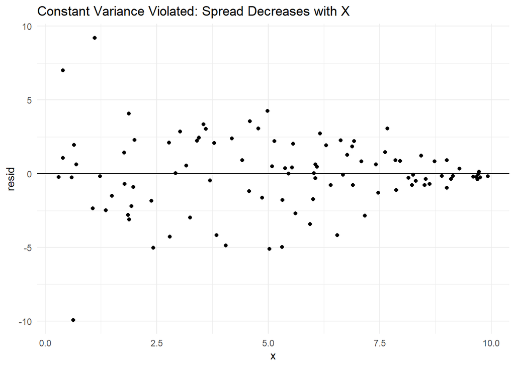

```r
resid_plot(heteroskedastic_data2) +
  ggtitle("Constant Variance Violated: Spread Decreases with X")
```

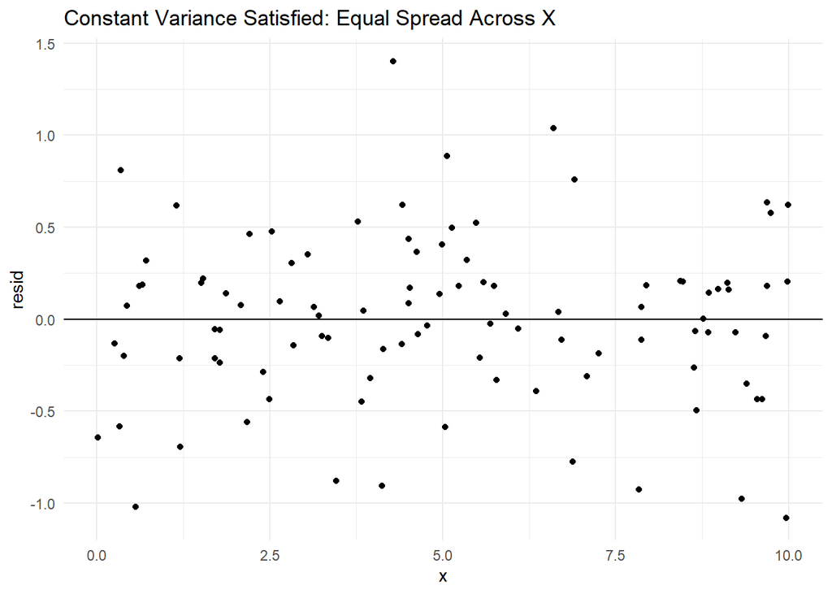

```r
resid_plot(linear_data) +
  ggtitle("Constant Variance Satisfied: Equal Spread Across X")
```

### Monona data

The lake monona model appears to be well fit.

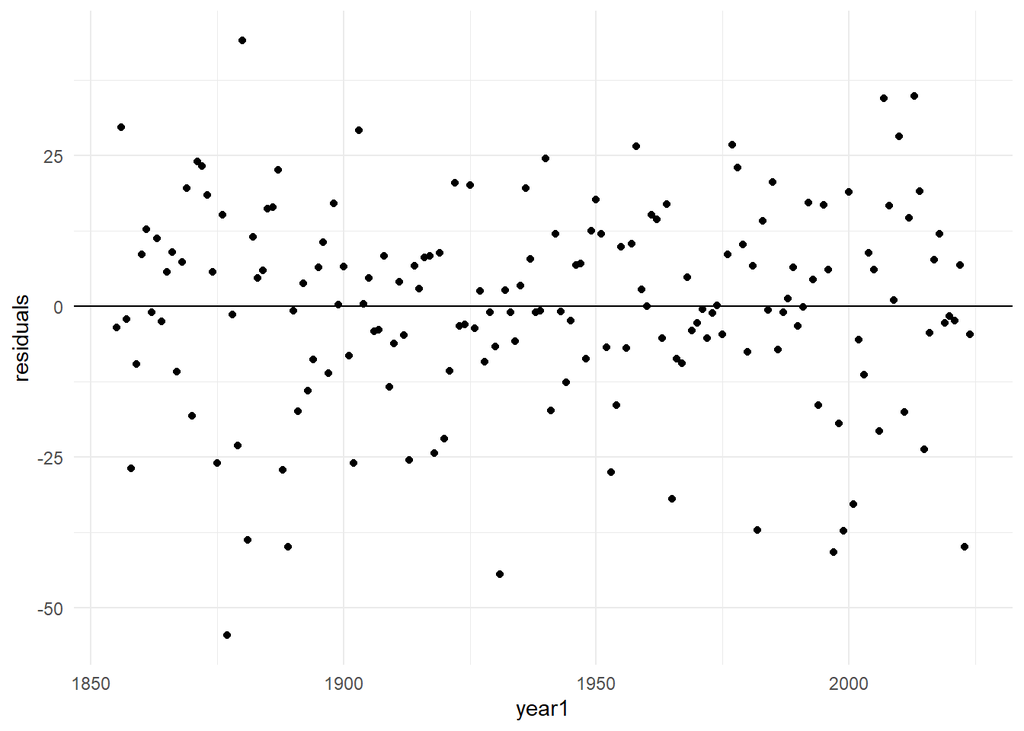

```r
monona_resids %>%
  ggplot(aes(x = year1, y = residuals)) +
  geom_point() +
  geom_hline(yintercept = 0)
```

## Prediction

How tall was Riley at age 78 months?

```r
ggplot(riley_2_8, aes(x = age, y = height)) +
  geom_point() +
  geom_smooth(se = FALSE, method = "lm") +
  geom_point(aes(x = new_x, y = new_y), color="red", size=4) +
  geom_vline(xintercept = 78, color="red", linetype="dashed") +
  geom_hline(yintercept = 49.78977, color = "red", linetype = "dashed") +
  ylab("Height (inches)") +
  xlab("Age (months)")
```

[output not shown]

[output not shown]

```r
30.25 + (0.25 * 78)
```

```
## [1] 49.75
```

```r
# or

predict(height_mod, newdata = tibble(age = 78))
```

```
##        1
## 49.78977
```

### Monona data

According to the linear model, what will be the duration of a future freeze? Set `year1` to be a number 2026 or greater.

```r
lake_mod <- lm(duration ~ year1, data = monona)
```

We have to be mindful when doing prediction. Extrapolation can be dangerous - for example, how long will the freeze duration in year 2400 be?